# Exploratory Data Analysis

Bourbon0212

2018/7/13

- Categorical Data
- Numerical Data
- Numerical Summaries
- Case Study

# **Categorical Data**

**Contingency Table**

- Reviews: **[Factors](https://bourbon0212.github.io/NTU-CS-X/Week1/hw1.html#1.5)**
- Reviews: **[Dataframe](https://bourbon0212.github.io/NTU-CS-X/Week1/hw1.html#1.6)**
- levels(): To show the levels of the factors.
- Use ‘$’ to select a specific row or column.
- table(): To generate ‘Contingency table’.

```r
library(readr)
comics <- read_csv('https://assets.datacamp.com/production/course_1796/datasets/comics.csv')
comics[1,]
```

```
## # A tibble: 1 x 11
##   name        id     align eye    hair   gender gsm   alive    appearances
##   <chr>       <chr>  <chr> <chr>  <chr>  <chr>  <chr> <chr>          <int>
## 1 Spider-Man~ Secret Good  Hazel~ Brown~ Male   <NA>  Living ~        4043
## # ... with 2 more variables: first_appear <chr>, publisher <chr>
```

```r
levels(comics$align)
```

```r
table(comics$align, comics$gender)
```

```
##
##                      Female Male Other
##   Bad                  1573 7561    32
##   Good                 2490 4809    17
##   Neutral               836 1799    17
##   Reformed Criminals      1    2     0
```

**Dropping Levels**

The contingency table from the last exercise revealed that there are some levels that have very low counts.

- Reviews: **[filter()](https://bourbon0212.github.io/NTU-CS-X/Week1/hw1.html#3.1)** for **Data Wrangling**
- droplevels(): Drops levels that don’t exist in a dataset.

Notice that after dropping levels, ‘Reformed Criminals’ doesn’t exist anymore.

```r
library(dplyr)
#Remove align level
comics <- comics %>%
  filter(align != 'Reformed Criminals') %>%
  droplevels()
table(comics$align, comics$gender)
```

```
##
##           Female Male Other
##   Bad       1573 7561    32
##   Good      2490 4809    17
##   Neutral    836 1799    17
```

**Graph: Side-by-side Barcharts**

While a contingency table represents the counts numerically, it’s often more useful to represent them graphically.

- Reviews: **[ggplot()](https://bourbon0212.github.io/NTU-CS-X/Week1/hw1.html#3.2)** for **Data Visualization**

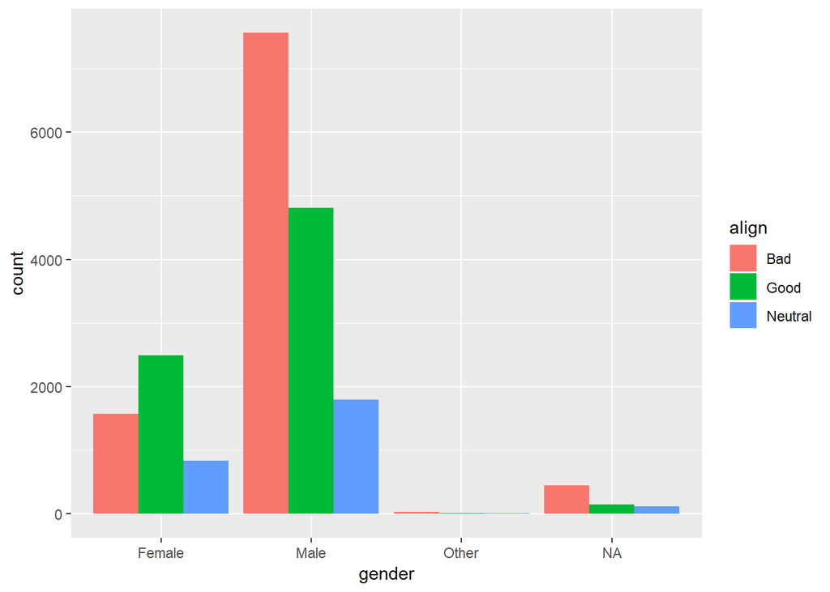

```r
library(ggplot2)
ggplot(comics, aes(x = gender, fill = align)) +
  geom_bar(position = "dodge") + #Decide whether to stack the graph or not.
  theme(axis.text.x = element_text(angle = 0 ))#Decide the element text of x axis displaying angle.
```

Besides counts graphs, we can also make proportional graphs.

```r
tab <- table(comics$align, comics$gender)
options(scipen = 999, digits = 3) # Print fewer digits
prop.table(tab)     #Joint proportions
```

```
##
##             Female     Male    Other
##   Bad     0.082210 0.395160 0.001672
##   Good    0.130135 0.251333 0.000888
##   Neutral 0.043692 0.094021 0.000888
```

```r
prop.table(tab, 2)  #'2' means Conditional on columns, '1' means Condintional on rows.
```

```
##
##           Female  Male Other
##   Bad      0.321 0.534 0.485
##   Good     0.508 0.339 0.258
##   Neutral  0.171 0.127 0.258
```

By adding position = “fill” to geom_bar(), you are saying you want the bars to fill the entire height of the plotting window, thus displaying proportions and not raw counts.

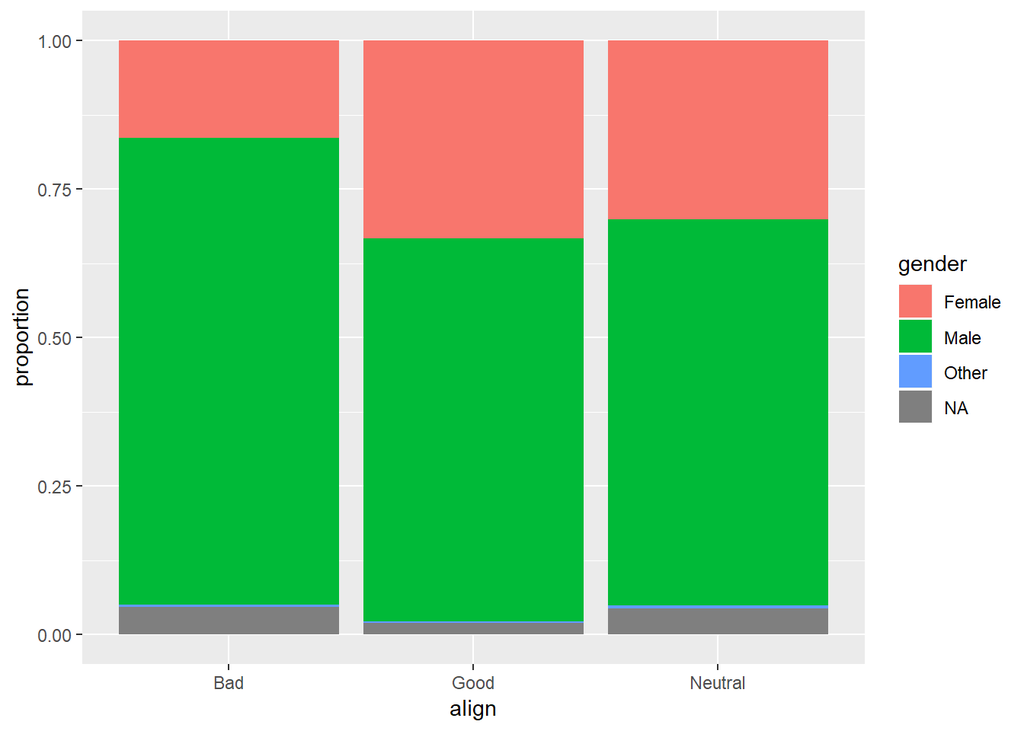

```r
ggplot(comics, aes(x = align, fill = gender)) +
  geom_bar(position = 'fill') +
  ylab("proportion")#Rename y axis.
```

**Distribution of One Categorical Variable**  
Notice the difference between geom_bar() & geom_col(). geom_bar() is **ONE** variable graph. However geom_col is **TWO** variable graph.  
* Use facet_wrap(~*) to breakdown a barchart.

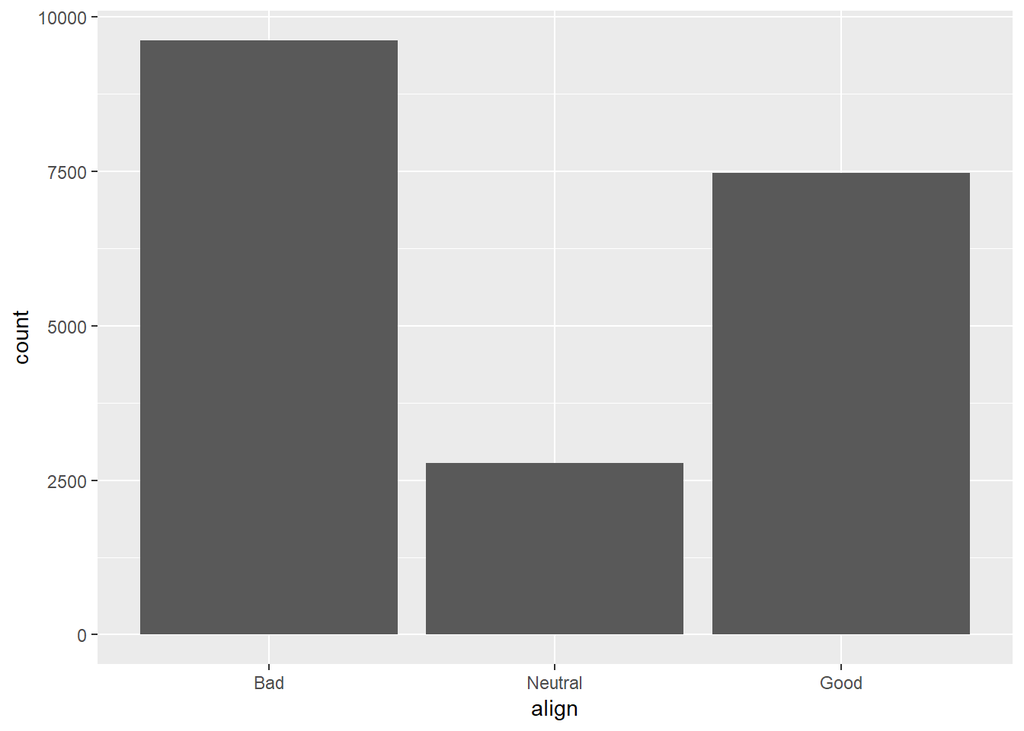

```r
#Change the order of the levels in align
comics$align <- factor(comics$align,
                       levels = c('Bad', 'Neutral', 'Good'))
#Create plot of align
ggplot(comics, aes(x = align)) +
  geom_bar()
```

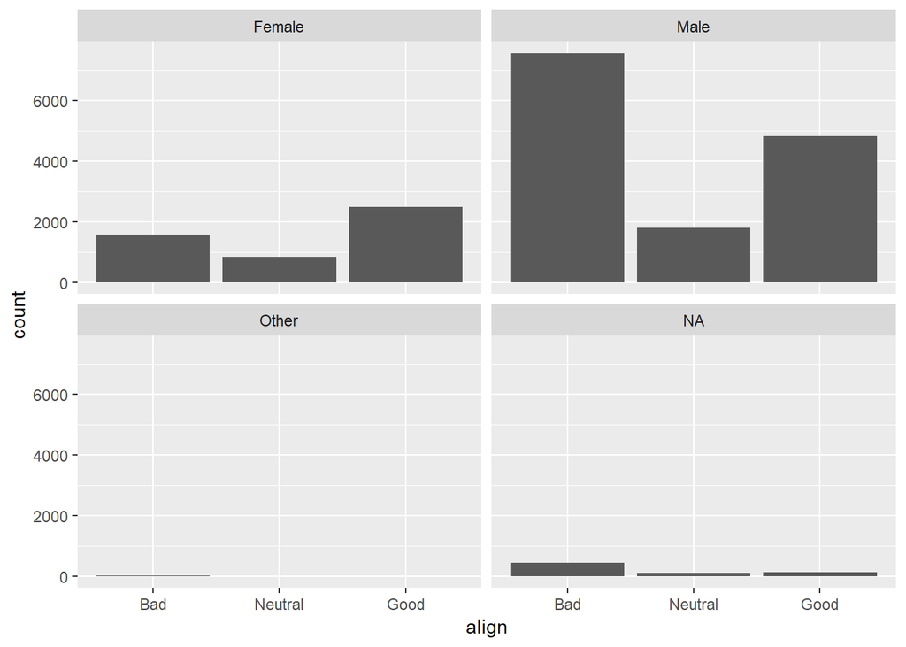

```r
#Plot of alignment broken down by gender
ggplot(comics, aes(x = align)) +
  geom_bar() +
  facet_wrap(~ gender)
```

# **Numerical Data**

**Faceted Histogram**

```r
library(readr)
cars <- read_csv('https://assets.datacamp.com/production/course_1796/datasets/cars04.csv')
cars[1,]
```

```
## # A tibble: 1 x 19
##   name    sports_car suv   wagon minivan pickup all_wheel rear_wheel  msrp
##   <chr>   <lgl>      <lgl> <lgl> <lgl>   <lgl>  <lgl>     <lgl>      <int>
## 1 Chevro~ FALSE      FALSE FALSE FALSE   FALSE  FALSE     FALSE      11690
## # ... with 10 more variables: dealer_cost <int>, eng_size <dbl>,
## #   ncyl <int>, horsepwr <int>, city_mpg <int>, hwy_mpg <int>,
## #   weight <int>, wheel_base <int>, length <int>, width <int>
```

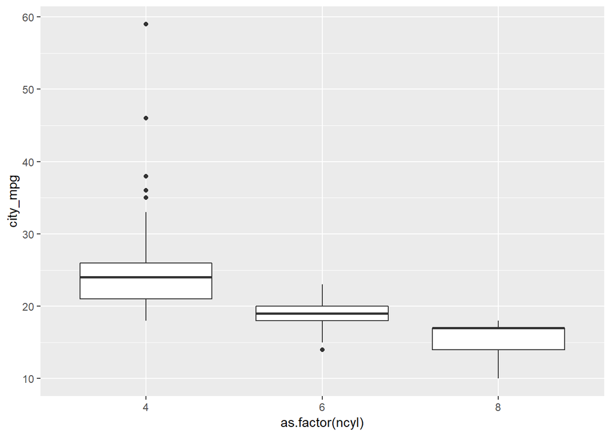

```r
#Filter cars with 4, 6, 8 cylinders
common_cyl <- filter(cars, ncyl %in% c(4, 6, 8))
#Create box plots of city mpg by ncyl
ggplot(common_cyl, aes(x = as.factor(ncyl), y = city_mpg)) +
  geom_boxplot()
```

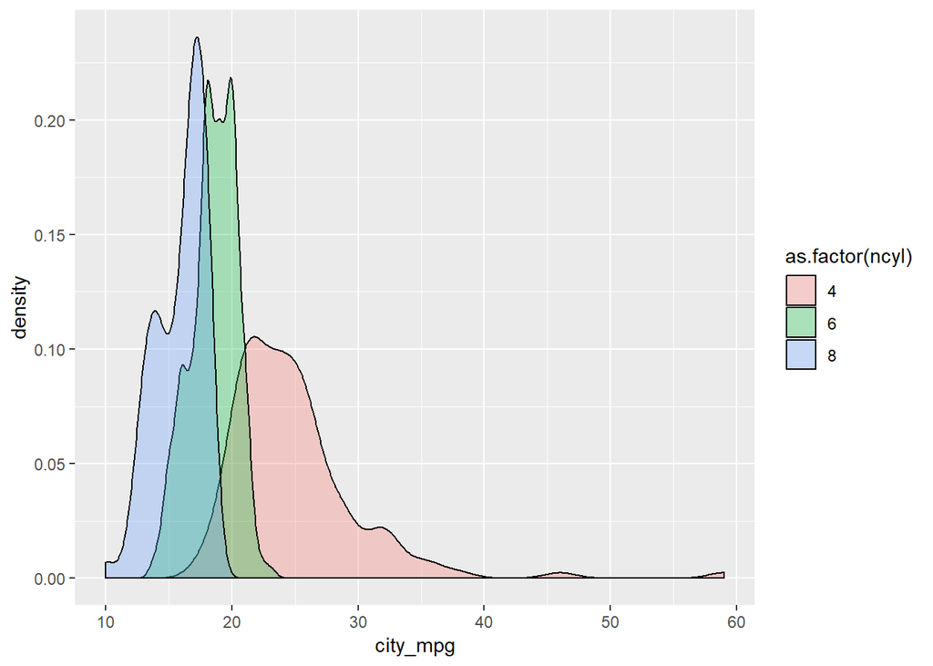

```r
#Create overlaid density plots for same data
ggplot(common_cyl, aes(x = city_mpg, fill = as.factor(ncyl))) +
  geom_density(alpha = .3)
```

According to this graph, we can conclude that:

- The highest mileage cars have 4 cylinders.
- The typical 4 cylinder car gets better mileage than the typical 6 cylinder car, which gets better mileage than the typical 8 cylinder car.
- Most of the 4 cylinder cars get better mileage than even the most efficient 8 cylinder cars.
- The variability in mileage of 8 cylinder cars seem much smaller than that of 4 cylinder cars.

**Distribution of One Numerical Variable**

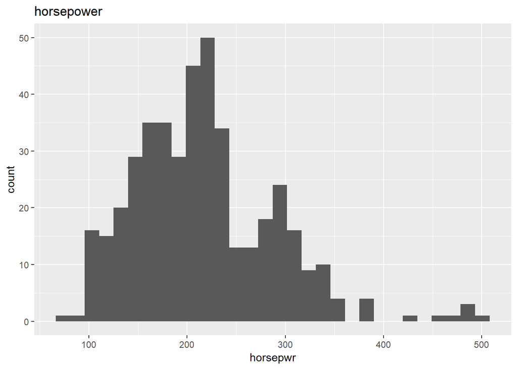

```r
#Create hist of horsepwr
cars %>%
  ggplot(aes(x = horsepwr)) +
  geom_histogram() +
  ggtitle('horsepower')
```

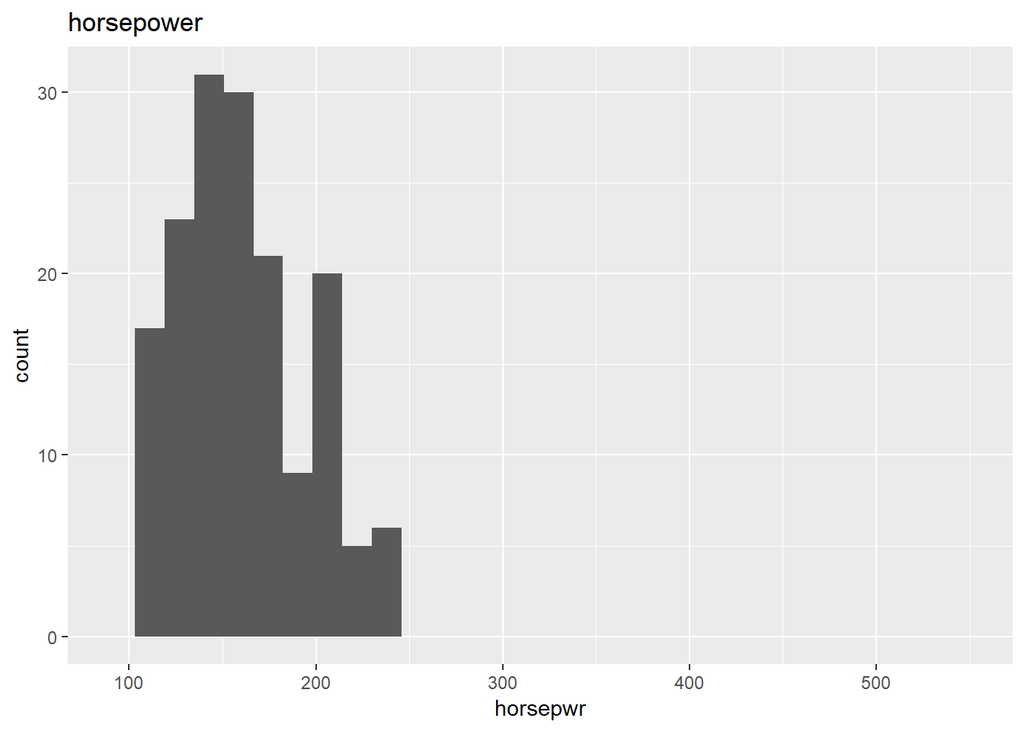

```r
#Create hist of horsepwr for affordable cars
cars %>%
  filter(msrp < 25000) %>%
  ggplot(aes(x = horsepwr)) +
  geom_histogram() +
  xlim(c(90, 550)) +
  ggtitle('horsepower')
```

Compare these two graphs, notice that afordable cars tend to has less horesepower. NO cars in the less expensive range exceed 250 horsepower.

**BinWidth**  
As binwidth becomes larger, the graphh becomes smoother. It’s crucial to derermine how large is the binwidth.

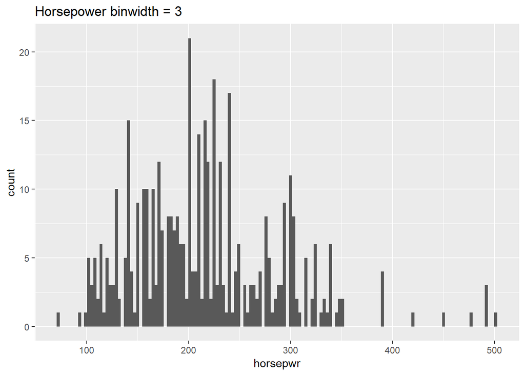

```r
#Create hist of horsepwr with binwidth of 3
cars %>%
  ggplot(aes(x = horsepwr)) +
  geom_histogram(binwidth = 3) +
  ggtitle('Horsepower binwidth = 3')
```

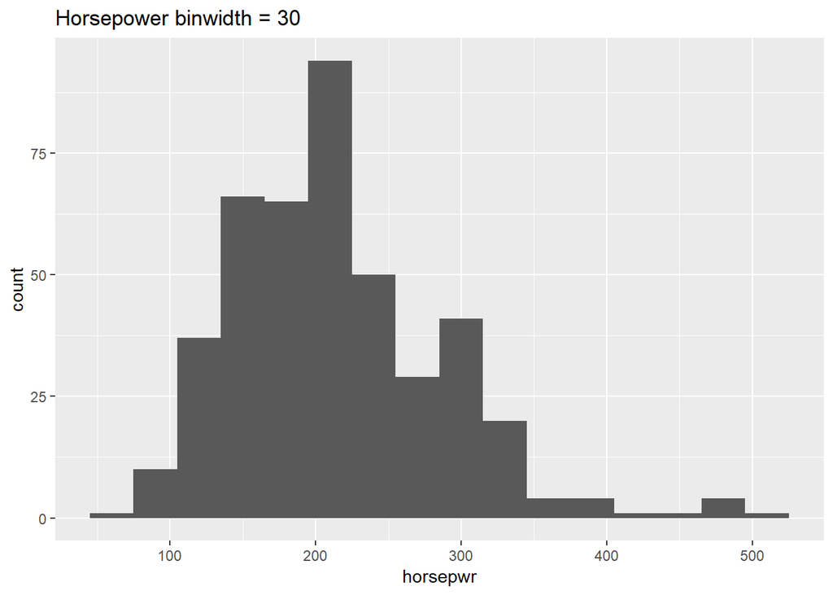

```r
#Change binwidth to 30
cars %>%
  ggplot(aes(x = horsepwr)) +
  geom_histogram(binwidth = 30) +
  ggtitle('Horsepower binwidth = 30')
```

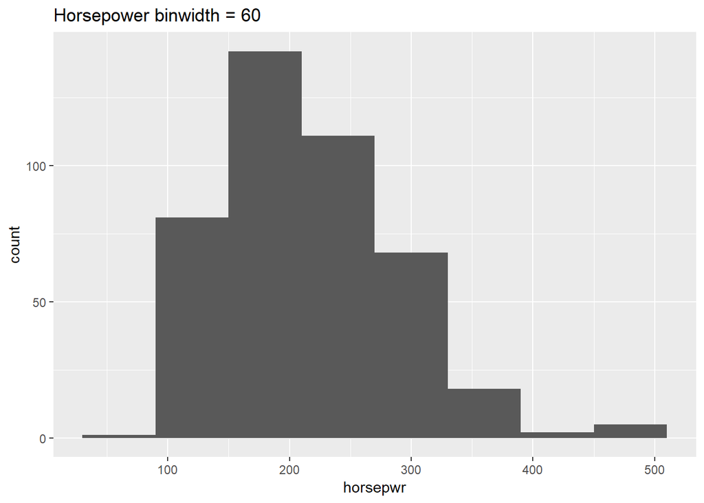

```r
#Change binwidth to 60
cars %>%
  ggplot(aes(x = horsepwr)) +
  geom_histogram(binwidth = 60) +
  ggtitle('Horsepower binwidth = 60')
```

**Density & BoxPlots**

- Reviews: **[Boxplots](https://bourbon0212.github.io/NTU-CS-X/Week1/hw1.html#3.4)**  
  Both density plots and box plots display the central tendency and spread of the data, but the box plot is more robust to **outliers**.

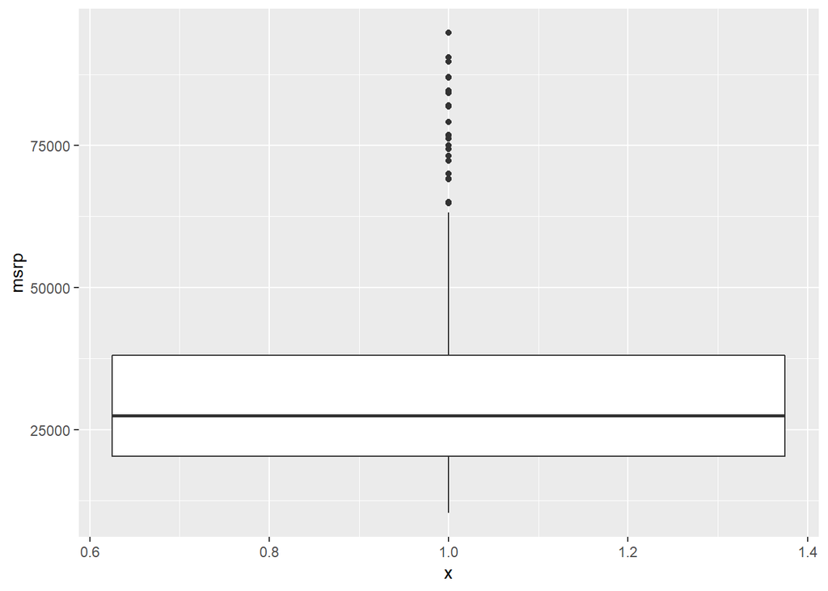

```r
#Exclude outliers from data
cars_no_out <- cars %>%
  filter(msrp < 100000)
#Construct box plot of msrp using the reduced dataset
cars_no_out %>%
  ggplot(aes(x = 1, y = msrp)) +
  geom_boxplot()
```

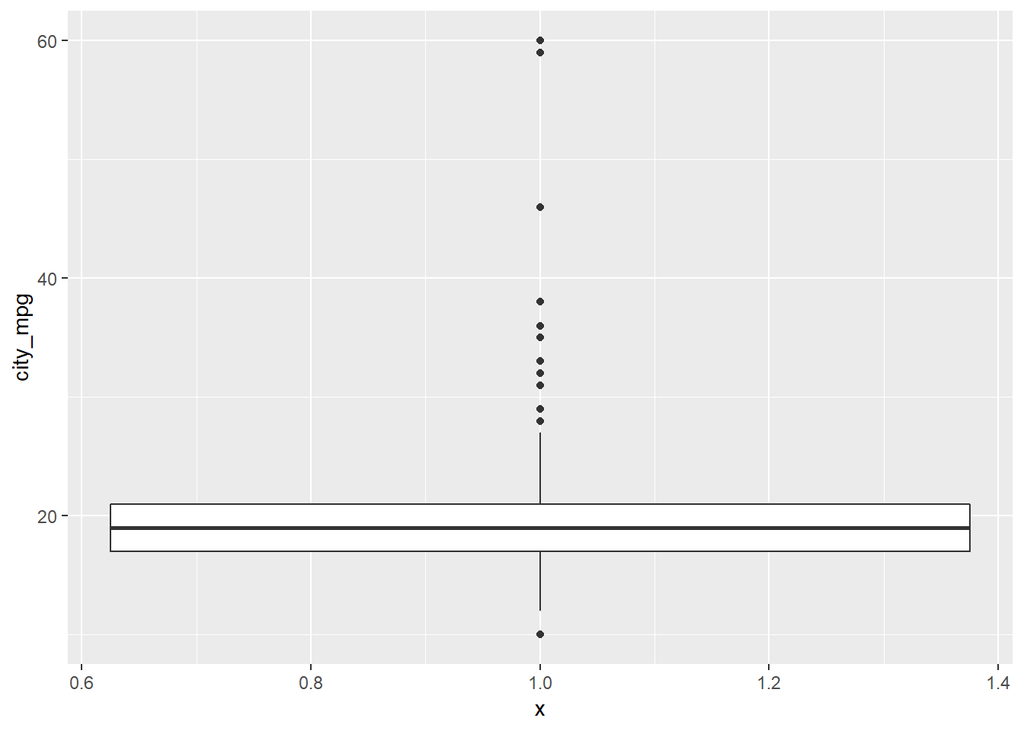

```r
#Create plot of city_mpg
cars %>%
  ggplot(aes(x = 1, y = city_mpg)) +
  geom_boxplot()
```

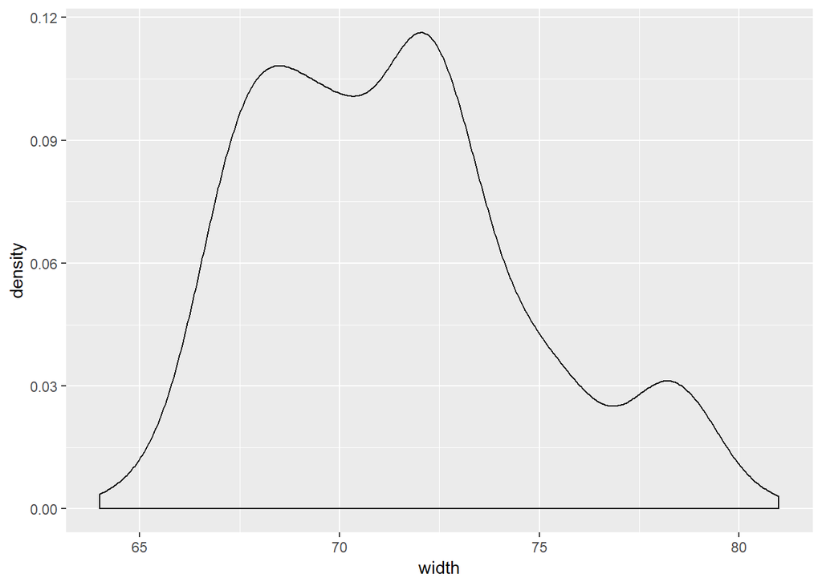

```r
#Create plot of width
cars %>%
  ggplot(aes(x = width)) +
  geom_density()
```

Because the city_mpg variable has a much wider range with its outliers, it’s best to display its distribution as a box plot.

**Higher Dimensions**

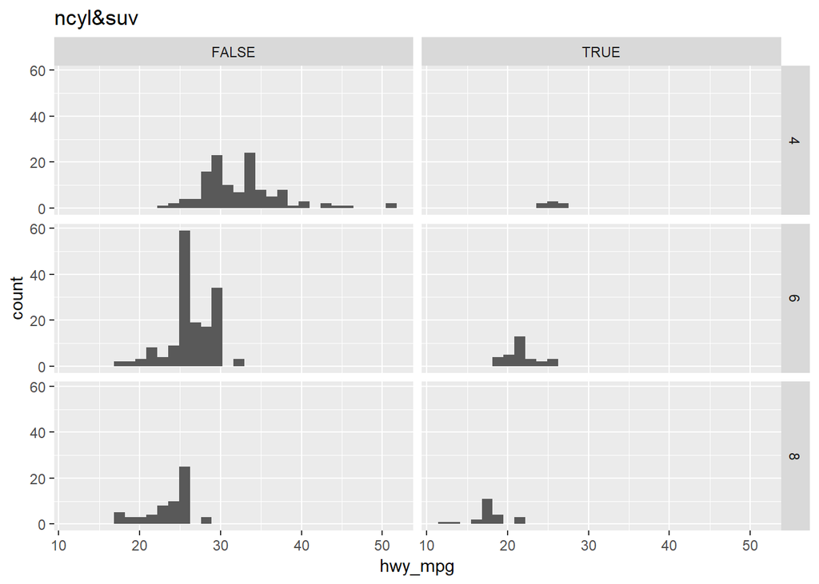

```r
common_cyl %>%
  ggplot(aes(x = hwy_mpg)) +
  geom_histogram() +
  facet_grid(ncyl ~ suv) +
  ggtitle('ncyl&suv')
```

Across both SUVs and non-SUVs, mileage tends to decrease as the number of cylinders increases according to the picture.